# DSMI - Data Cleaning, Summary, and Visualizations

Charlie Whittaker

2/18/2026

```r
library(openxlsx)
library(tidyverse)
library(ggrepel)
library(ggpubr)
library(purrr)
library(knitr)
library(lubridate)
library(patchwork)
```

# Data Import

```r
ilabs <- read.xlsx("../data/stock_ilabs.xlsx")
ilabs.dsmi <- ilabs %>% dplyr::filter(Core.Name == "Bioinformatics and Computing Core")
rm(ilabs)
```

### Repair ilabs date

```r
ilabs.dsmi$Purchase.Date <- as.Date(ilabs.dsmi$Purchase.Date, origin = "1899-12-30")
```

## Read in bmc-external

```r
bmc.ext <- read.xlsx("../data/ExtUsage2025_2510.xlsx")
```

### Data Repair - bmc external

#### simplify the imported dataframe

This first step identifies empty or near-empty columns and summarizes the results. The bmc.ext data as none of these low complexity columns.

```r
# simple.cols <- map_df(names(bmc.ext), ~{
#   col <- bmc.ext[[.]]
#   n_unique <- n_distinct(col[!is.na(col)])
#
#   tibble(
#     column = .,
#     value = if_else(all(is.na(col)),
#                     "empty",
#                     if_else(n_unique == 1,
#                            as.character(unique(col[!is.na(col)])[1]),
#                            NA_character_))
#   )
# }) %>%
#   filter(!is.na(value))
#
# kable(simple.cols, format = "simple")
```

If the data frame had these columns, they could be excluded with this code.

```r
# cat("Dimensions before simple column exclusion:", dim(bmc.ext), "\n")
# bmc.ext <- bmc.ext %>% dplyr::select(-all_of(simple.cols$column))
# cat("Dimensions after simple column exclusion:", dim(bmc.ext), "\n")
```

#### Repair date

```r
bmc.ext$Purchase.Date <- as.Date(bmc.ext$DATE, origin = "1899-12-30")
```

#### Select DSMI-related charges from bmc.ext

```r
bmc.ext.dsmi <- bmc.ext %>% dplyr::filter(TYPE %in% c("Bioinformatics", "Computing"))
```

#### Compare column names in ilabs.dsmi and bmc.ext

```r
colnames(ilabs.dsmi)
```

```
##  [1] "Service.ID"          "Service.Type"        "Customer.Name"
##  [4] "Customer.Lab"        "Customer.Department" "Customer.Institute"
##  [7] "Charge.Name"         "Notes"               "Unit.of.Measure"
## [10] "Quantity"            "Price"               "Total.Price"
## [13] "Price.Type"          "Purchase.Date"       "Core.Name"
## [16] "Charge.ID"           "Center"              "Category"
## [19] "Usage.Type"
```

```r
colnames(bmc.ext.dsmi)
```

```
##  [1] "_ID"           "PROJID"        "LAB"           "USER"
##  [5] "DATE"          "DETAIL"        "NUM"           "COST"
##  [9] "CostObj"       "TargetObject"  "TYPE"          "Purchase.Date"
```

#### Rename columns to match ilabs

```r
bmc.ext.dsmi <- bmc.ext.dsmi %>% dplyr::rename(Customer.Name = USER)
bmc.ext.dsmi <- bmc.ext.dsmi %>% dplyr::mutate(Service.ID = `_ID`)
bmc.ext.dsmi <- bmc.ext.dsmi %>% dplyr::rename(Customer.Lab = LAB)
bmc.ext.dsmi <- bmc.ext.dsmi %>% dplyr::rename(Charge.Name = DETAIL)
bmc.ext.dsmi <- bmc.ext.dsmi %>% dplyr::rename(Quantity = NUM)
bmc.ext.dsmi <- bmc.ext.dsmi %>% dplyr::rename(Total.Price = COST)
bmc.ext.dsmi <- bmc.ext.dsmi %>% dplyr::rename(Category = TYPE)
```

#### Add missing columns needed to match ilabs data

```r
bmc.ext.dsmi <- bmc.ext.dsmi %>% dplyr::mutate(Price = round(Total.Price/Quantity,2))
bmc.ext.dsmi <- bmc.ext.dsmi %>% dplyr::mutate(Service.Type = "ToUpdate")
bmc.ext.dsmi <- bmc.ext.dsmi %>% dplyr::mutate(Customer.Department = "")
bmc.ext.dsmi <- bmc.ext.dsmi %>% dplyr::mutate(Customer.Institute = "")
bmc.ext.dsmi <- bmc.ext.dsmi %>% dplyr::mutate(Unit.of.Measure = "ToUpdate")
bmc.ext.dsmi <- bmc.ext.dsmi %>% dplyr::mutate(Price.Type = "")
bmc.ext.dsmi <- bmc.ext.dsmi %>% dplyr::mutate(Core.Name = "bmc.ext")
bmc.ext.dsmi <- bmc.ext.dsmi %>% dplyr::mutate(Center = "")
bmc.ext.dsmi <- bmc.ext.dsmi %>% dplyr::mutate(Usage.Type = "")
bmc.ext.dsmi <- bmc.ext.dsmi %>% dplyr::mutate(Notes = "")
bmc.ext.dsmi <- bmc.ext.dsmi %>% dplyr::mutate(Charge.ID = "")
```

#### Select ilabs columns from bmc.ext.dsmi

```r
bmc.ext.dsmi.to_rbind <- bmc.ext.dsmi %>%
  dplyr::select(Service.ID, Service.Type, Customer.Name, Customer.Lab, Customer.Department,
                Customer.Institute, Charge.Name, Notes, Unit.of.Measure, Quantity, Price,
                Total.Price, Price.Type, Purchase.Date, Core.Name, Charge.ID, Center, Category,
                Usage.Type)
```

#### Check the column names

```r
colnames(ilabs.dsmi)
```

```
##  [1] "Service.ID"          "Service.Type"        "Customer.Name"
##  [4] "Customer.Lab"        "Customer.Department" "Customer.Institute"
##  [7] "Charge.Name"         "Notes"               "Unit.of.Measure"
## [10] "Quantity"            "Price"               "Total.Price"
## [13] "Price.Type"          "Purchase.Date"       "Core.Name"
## [16] "Charge.ID"           "Center"              "Category"
## [19] "Usage.Type"
```

```r
colnames(bmc.ext.dsmi.to_rbind)
```

```
##  [1] "Service.ID"          "Service.Type"        "Customer.Name"
##  [4] "Customer.Lab"        "Customer.Department" "Customer.Institute"
##  [7] "Charge.Name"         "Notes"               "Unit.of.Measure"
## [10] "Quantity"            "Price"               "Total.Price"
## [13] "Price.Type"          "Purchase.Date"       "Core.Name"
## [16] "Charge.ID"           "Center"              "Category"
## [19] "Usage.Type"
```

### Join ilabs and bmc.ext.dsmi

```r
dsmi.final <- rbind(ilabs.dsmi,bmc.ext.dsmi.to_rbind)
```

### Check dates before reporting range selection

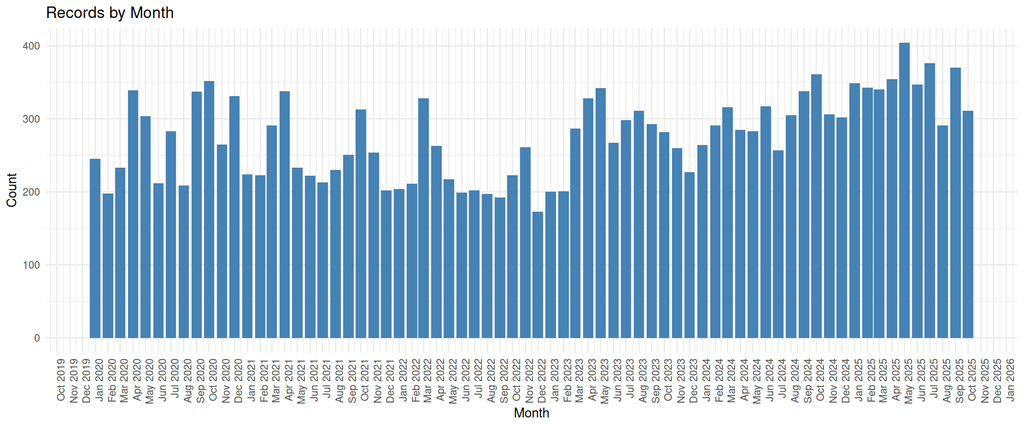

```r
dsmi.final %>%
  mutate(Year_Month = floor_date(Purchase.Date, "month")) %>%
  count(Year_Month) %>%
  arrange(Year_Month) %>%
  ggplot(aes(x = Year_Month, y = n)) +
  geom_col(fill = "steelblue") +
  scale_x_date(date_labels = "%b %Y", date_breaks = "1 month") +
  labs(title = "Records by Month",
       x = "Month",
       y = "Count") +
  theme_minimal() +
  theme(axis.text.x = element_text(angle = 90, hjust = 1))
```

### Select reporting date range

```r
cat("Dimensions of dsmi.final before reporting range selection:", dim(dsmi.final), "\n")
```

```
## Dimensions of dsmi.final before reporting range selection: 19378 19
```

```r
dsmi.final <- dsmi.final %>% dplyr::filter(between(Purchase.Date, as.Date("2020-05-01"), as.Date("2025-10-31")))
cat("Dimensions of dsmi.final after reporting range selection:", dim(dsmi.final), "\n")
```

```
## Dimensions of dsmi.final after reporting range selection: 18349 19
```

### Check dates after reporting range selection

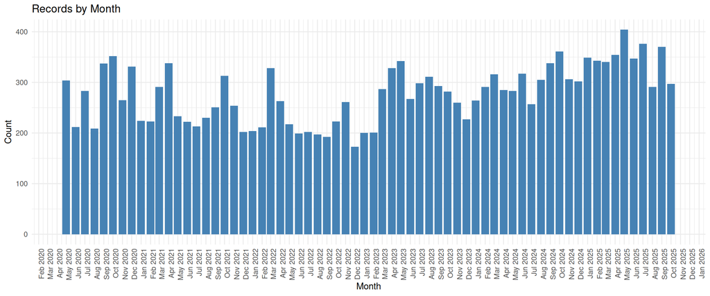

```r
dsmi.final %>%
  mutate(Year_Month = floor_date(Purchase.Date, "month")) %>%
  count(Year_Month) %>%
  arrange(Year_Month) %>%
  ggplot(aes(x = Year_Month, y = n)) +
  geom_col(fill = "steelblue") +
  scale_x_date(date_labels = "%b %Y", date_breaks = "1 month") +
  labs(title = "Records by Month",
       x = "Month",
       y = "Count") +
  theme_minimal() +
  theme(axis.text.x = element_text(angle = 90, hjust = 1))
```

# Faculty Annotation Work

### Import faculty key data

```r
fac.key <- read.xlsx("../data/FacultyKeys.xlsx")
```

### Associate Faculty.Key with dsmi.final

```r
dsmi.final <- dsmi.final %>%
  left_join(fac.key %>%
              select(ValueInData, Faculty.Key) %>%
              distinct(),
            by = c("Customer.Lab" = "ValueInData"))
```

### Import sponsor annotation data

```r
fac.annot <- read.xlsx("../data/annotated.Faculty.Keys.xlsx")
```

### Join to dsmi.final using Faculty.Key

```r
dsmi.final <- dsmi.final %>%
  dplyr::left_join(
    fac.annot %>% dplyr::select(Faculty.Key, IGT_DSMI_Sponsor),
    by = "Faculty.Key"
  )
```

### Simplify sponsor associations for plotting

#### Import simplified categories

```r
sponsor.toPlot <- read.xlsx("../data/sponsor.Keys.ForPlotting.xlsx")
sponsor.toPlot
```

```
##           Sponsor Sponsor_ForPlot
## 1       KI_member   Center_Member
## 2    KI_affiliate   Center_Member
## 3     MIT_sponsor     MIT_Sponsor
## 4 MIT_non_sponsor     Non_Sponsor
## 5        external     Non_Sponsor
## 6        industry     Non_Sponsor
```

#### Join simplified sponsor data to dsmi.final

```r
dsmi.final <- dsmi.final %>%
  dplyr::left_join(sponsor.toPlot, by = c("IGT_DSMI_Sponsor" = "Sponsor"))
```

# Service Annotation

This may be necessary to facilitate data type selections for plotting

## Gather categrories and output data

Information about what was done is stored in 2 columns: Service.Type and Charge.Name

```r
# dsmi.final <- dsmi.final %>%
#   mutate(Service.Group.working = case_when(
#     Core.Name == "Biopolymers & Proteomics Core" ~ Service.Type,
#     Core.Name == "metpro" ~ Charge.Name,
#     TRUE ~ NA_character_  # default for any other cases
#   ))
#
# cat("Dimensions of Service.Group.working dataframe:", dim(as.data.frame(table(dsmi.final$Service.Group.working))), "\n")
#
# msbp.Service.Group.working.df <- as.data.frame(table(dsmi.final$Service.Group.working))
# write.xlsx(msbp.Service.Group.working.df,file="msbp.Service.Group.working.df.xlsx")
```

## Import manually annotated service groups

Manually annotate Service.Group based on data in Service.Group.working and import the results

```r
# msbp.Service.Groups <- read.xlsx("../data/msbp.Service.Group.Annotation.xlsx")
```

## Join Service.Group to dsmi.final

```r
# dsmi.final <- dsmi.final %>%
#   dplyr::left_join(
#     msbp.Service.Groups %>% dplyr::select(Service.Group.working, Service.Group),
#     by = "Service.Group.working"
#   )
```

# Rate Modifiers

This is being paused now - using consistent units (each and hours instead)

## Import rate modifier data

```r
# rate.mod <- read.xlsx("../data/rateModifiers.xlsx")
# rate.mod
```

## Join the 2 different rate modifiers to dsmi.final using SponsorCategory

This should be validated by looking for Customer.Lab values that have more than 1 rate.modifier

```r
# msbp.final <- msbp.final %>%
#   left_join(
#     rate.mod %>% select(SponsorCategory, BP_modifier),
#     by = c("BioPol_Sponsor" = "SponsorCategory")
#   ) %>%
#   left_join(
#     rate.mod %>% select(SponsorCategory, metpro_modifier),
#     by = c("MetPro_Sponsor" = "SponsorCategory")
#   ) %>%
#   mutate(rate.modifier = case_when(
#     Core.Name == "Biopolymers & Proteomics Core" ~ BP_modifier,
#     Core.Name == "metpro" ~ metpro_modifier,
#     TRUE ~ NA_real_
#   )) %>%
#   select(-BP_modifier, -metpro_modifier)  # clean up temporary columns
```

## Create adjusted Total.Price values based on assigned rate.modifier values

```r
# msbp.final <- msbp.final %>% dplyr::mutate(Adjusted.Total.Price = Total.Price * rate.modifier)
```

# Data Visualizations

## Define Color Palette

```r
# Define colors for each Sponsor (adjust these hex codes as needed)
# Original palette
# sponsor_colors <- c(
#   "Center_Member" = "steelblue2",
#   "MIT_Sponsor" = "orange",
#   "Non_Sponsor" = "#C16644"
# )

# Colorblind safe 3
sponsor_colors <- c(
  "Center_Member" = "#56B4E9",
  "MIT_Sponsor" = "#E69F00",
  "Non_Sponsor" = "#009E73"
)

# Define order of sponsors for stacking (top to bottom)
sponsor_order <- c("Center_Member", "MIT_Sponsor", "Non_Sponsor")
```

## Training Data

### Extract the data from the main dataframe

```r
train <- dsmi.final %>% dplyr::filter(Category == "Training")
dim(train)
```

```
## [1] 1527   22
```

```r
old.train <- dsmi.final %>% dplyr::filter(Category == "Hours of Service " & Charge.Name == "Training Session")
dim(old.train)
```

```
## [1] 123  22
```

```r
train <- rbind(train,old.train)
dim(train)
```

```
## [1] 1650   22
```

### Check the results

```r
head(train)
```

```
##    Service.ID                                       Service.Type  Customer.Name
## 1 BCC-AA-1799 KI IGB / BioMicro Bioinformatics Training Sessions Adam Amsterdam
## 2 BCC-AA-1799 KI IGB / BioMicro Bioinformatics Training Sessions Adam Amsterdam
## 3 BCC-AA-1799 KI IGB / BioMicro Bioinformatics Training Sessions Adam Amsterdam
## 4 BCC-AA-1799 KI IGB / BioMicro Bioinformatics Training Sessions Adam Amsterdam
## 5 BCC-AA-1799 KI IGB / BioMicro Bioinformatics Training Sessions Adam Amsterdam
## 6 BCC-AA-1799 KI IGB / BioMicro Bioinformatics Training Sessions Adam Amsterdam
##                  Customer.Lab Customer.Department
## 1 Lees, Jacqueline (Koch) Lab
## 2 Lees, Jacqueline (Koch) Lab
## 3 Lees, Jacqueline (Koch) Lab
## 4 Lees, Jacqueline (Koch) Lab
## 5 Lees, Jacqueline (Koch) Lab
## 6 Lees, Jacqueline (Koch) Lab
##                      Customer.Institute
```

[output cut: 34 more lines]

### Prepare training pie chart

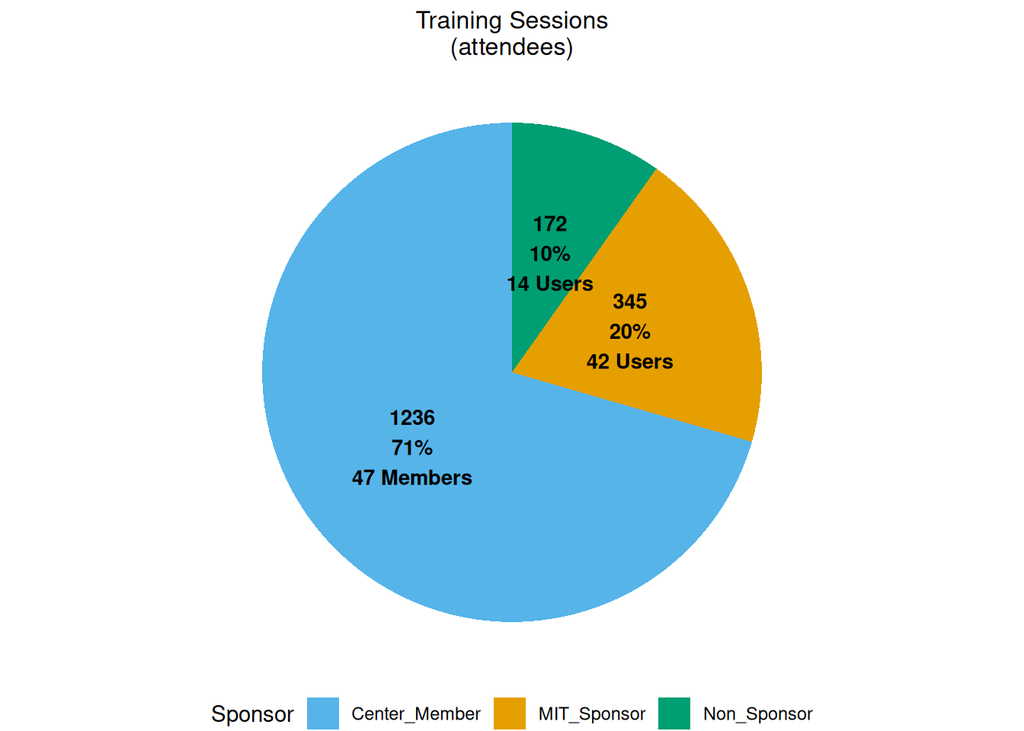

```r
train.pie <- train %>%
  mutate(Sponsor_ForPlot = factor(Sponsor_ForPlot, levels = sponsor_order)) %>%
  group_by(Sponsor_ForPlot) %>%
  summarise(Quantity = sum(round(Quantity,0)),
            Num_Labs = if_else(first(Sponsor_ForPlot) == "Center_Member",
                               n_distinct(Faculty.Key[IGT_DSMI_Sponsor == "KI_member"]),
                               n_distinct(Faculty.Key)),
            .groups = "drop") %>%
  mutate(Percent = round((Quantity / sum(Quantity)) * 100, 0),
         Lab_Label = if_else(Sponsor_ForPlot == "Center_Member",
                             paste0(Num_Labs, " Members"),
                             paste0(Num_Labs, " Users")),
         Label = paste0(Quantity, "\n", Percent, "%\n", Lab_Label)) %>%
  ggplot(aes(x = "", y = Quantity, fill = Sponsor_ForPlot)) +
  geom_col() +
  geom_text(aes(label = Label),
            position = position_stack(vjust = 0.5),
            size = 3.6,
            fontface = "bold",
            color = "black") +
  coord_polar("y", start = 0) +
  scale_fill_manual(values = sponsor_colors) +
  labs(title = "Training Sessions\n(attendees)",
       fill = "Sponsor") +
  theme_void() +
  theme(legend.position = "bottom",
        plot.title = element_text(size = 12,
                                  face = "plain",
                                  hjust = 0.5))

train.pie
```

## Project Hours Data

### Extract the data from the main dataframe

```r
hours <- dsmi.final %>% dplyr::filter(Category %in% c("Bioinformatics","Hours of Service ", "Prepaid Support"))
dim(hours)
```

```
## [1] 14063    22
```

### Identify rows to exclude from this selected group

```r
toExclude <- hours %>% dplyr::filter(Charge.Name %in% c("Bioinformatics Support",
                                                     "Custom Service: BMC ",
                                                     "Informatics Support FTE support",
                                                     "Training Session",
                                                     "Stem Cell Initiative Pipeline and ONT work",
                                                     "Informatics Support - FEB",
                                                     "Informatics Support - JAN",
                                                     "Prepaid Bioinformatics Support (KI)",
                                                     "Prepaid Bioinformatics Support"
                                                     ))
dim(toExclude)
```

```
## [1] 888  22
```

```r
table(toExclude$Charge.Name)
```

```
##
##                     Bioinformatics Support
##                                          1
##                       Custom Service: BMC
##                                          2
##                  Informatics Support - FEB
##                                          1
##                  Informatics Support - JAN
##                                          1
##            Informatics Support FTE support
##                                          1
##             Prepaid Bioinformatics Support
##                                        633
##        Prepaid Bioinformatics Support (KI)
##                                        120
## Stem Cell Initiative Pipeline and ONT work
##                                          6
##                           Training Session
##                                        123
```

### Negate the selection to exclude

```r
hours <- hours %>% dplyr::filter(!Charge.Name %in% c("Bioinformatics Support",
                                                     "Custom Service: BMC ",
                                                     "Informatics Support FTE support",
                                                     "Training Session",
                                                     "Stem Cell Initiative Pipeline and ONT work",
                                                     "Informatics Support - FEB",
                                                     "Informatics Support - JAN",
                                                     "Prepaid Bioinformatics Support (KI)",
                                                     "Prepaid Bioinformatics Support"
                                                     ))
```

### Check the data

```r
dim(hours)
```

```
## [1] 13175    22
```

```r
table(hours$Charge.Name)
```

```
##
##                         Informatics Support
##                                          46
##                             Project - Allen
##                                           3
##                           Project - Charlie
##                                        2302
##                          Project - CharlieD
##                                        1461
##                             Project - CO-OP
##                                         257
## Project - CO-OP (for sponsor projects only)
##                                          69
##                          Project - Dikshant
##                                         633
##                              Project - Duan
##                                        1635
##                           Project - Huiming
##                                        1394
##                           Project - Jingzhi
##                                          87
##                            Project - Nathan
##                                          68
##                            Project - Stuart
##                                           9
##                            Project - Taisha
##                                        1029
##                           Project - Vincent
##                                        3989
##                               Project- Yann
##                                         192
##                             Teaching - Duan
##                                           1
```

```r
table(hours$Unit.of.Measure)
```

```
##
##      Day     each     hour ToUpdate
##      257       82    12790       46
```

```r
table(hours$Price)
```

```
##
##    0   80   85   90  110  115  130  140  145  150  160  165  180
## 8087  128 1627 2706   90  229   26   12    4    1  214   43    7
```

This value is currently reported in days. For each unit, multiple by 2 - each Co-OP day is counted as 2 hours.

```r
hours <- hours %>% dplyr::mutate(
  Quantity = dplyr::case_when(
    Charge.Name == "Project - CO-OP" ~ Quantity * 2,
    TRUE ~ Quantity
  )
)
```

One value in the dataframe has a Quantity = NA, this will set it to 0

```r
hours <- hours %>% dplyr::mutate(
  Quantity = dplyr::case_when(
    is.na(Quantity) ~ 0,
    TRUE ~ Quantity
  )
)
```

### hours object needs to by split into 2 set, one project hours, one data managment

```r
hours.dmac <- hours %>% dplyr::filter(Service.ID %in% c("\tBCC-KAMM prepaid bioinformatics 2023-0.2",
  "BCC-ANK-prepaid bioinformatics-0.2",
  "BCC-BPE-1820",
  "BCC-BPE-1828",
  "BCC-CG-1442",
  "BCC-DAL-1627",
  "BCC-ENGELWARD prepaid bioinformatics 2022-0.45",
  "BCC-ENGELWARD prepaid bioinformatics 2023-0.45",
  "BCC-ENGELWARD prepaid bioinformatics-0.425",
  "BCC-FMW-2647",
  "BCC-KAMM prepaid bioinformatics 2022-0.2",
  "BCC-KAMM prepaid bioinformatics-0.2",
  "BCC-Lauffenburger/Data Management Core (IMPAcTB)-prepaid bioinformatics",
  "BCC-LGG-2241",
  "BCC-LGG-prepaid bioinformatics-0.2",
  "BCC-SELIN-prepaid bioinformatics 0.935 - 2019-2020",
  "BCC-WHITE prepaid bioinformatics-0.2"))

hours.project <- hours %>% dplyr::filter(!Service.ID %in% c("\tBCC-KAMM prepaid bioinformatics 2023-0.2",
  "BCC-ANK-prepaid bioinformatics-0.2",
  "BCC-BPE-1820",
  "BCC-BPE-1828",
  "BCC-CG-1442",
  "BCC-DAL-1627",
  "BCC-ENGELWARD prepaid bioinformatics 2022-0.45",
  "BCC-ENGELWARD prepaid bioinformatics 2023-0.45",
  "BCC-ENGELWARD prepaid bioinformatics-0.425",
  "BCC-FMW-2647",
  "BCC-KAMM prepaid bioinformatics 2022-0.2",
  "BCC-KAMM prepaid bioinformatics-0.2",
  "BCC-Lauffenburger/Data Management Core (IMPAcTB)-prepaid bioinformatics",
  "BCC-LGG-2241",
  "BCC-LGG-prepaid bioinformatics-0.2",
  "BCC-SELIN-prepaid bioinformatics 0.935 - 2019-2020",
  "BCC-WHITE prepaid bioinformatics-0.2"))
```

### Check the data

```r
dim(hours)
```

```
## [1] 13175    22
```

```r
dim(hours.dmac)
```

```
## [1] 3795   22
```

```r
dim(hours.project)
```

```
## [1] 9380   22
```

### Add hours for Anderson Scott’s work

Import the data exported from PMIT

```r
as.hours <- read.xlsx("AS_hours_toDSMI.xlsx")
```

Make repairs prior to merge

```r
as.hours <- as.hours %>% rename(IGT_DSMI_Sponsor = PMIT_Sponsor)
as.hours <- as.hours %>% dplyr::select(-Charge.Name.Short)
```

Add Anderson’s hours to the hours.project

```r
hours.project <- rbind(hours.project,as.hours)
```

### Prepare project hours pie chart

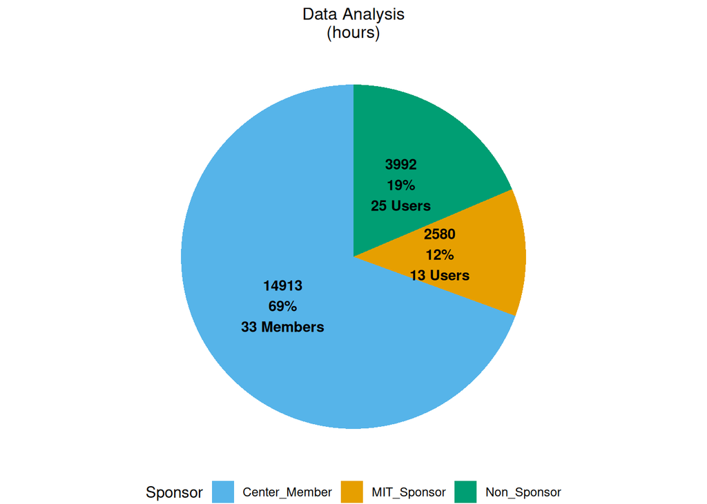

```r
proj.hours.pie <- hours.project %>%
  mutate(Sponsor_ForPlot = factor(Sponsor_ForPlot, levels = sponsor_order)) %>%
  group_by(Sponsor_ForPlot) %>%
  summarise(Quantity = sum(round(Quantity,0)),
            Num_Labs = if_else(first(Sponsor_ForPlot) == "Center_Member",
                               n_distinct(Faculty.Key[IGT_DSMI_Sponsor == "KI_member"]),
                               n_distinct(Faculty.Key)),
            .groups = "drop") %>%
  mutate(Percent = round((Quantity / sum(Quantity)) * 100, 0),
         Lab_Label = if_else(Sponsor_ForPlot == "Center_Member",
                             paste0(Num_Labs, " Members"),
                             paste0(Num_Labs, " Users")),
         Label = paste0(Quantity, "\n", Percent, "%\n", Lab_Label)) %>%
  ggplot(aes(x = "", y = Quantity, fill = Sponsor_ForPlot)) +
  geom_col() +
  geom_text(aes(label = Label),
            position = position_stack(vjust = 0.5),
            size = 3.6,
            fontface = "bold",
            color = "black") +
  coord_polar("y", start = 0) +
  scale_fill_manual(values = sponsor_colors) +
  labs(title = "Data Analysis\n(hours)",
       fill = "Sponsor") +
  theme_void() +
  theme(legend.position = "bottom",
        plot.title = element_text(size = 12,
                                  face = "plain",
                                  hjust = 0.5))

proj.hours.pie
```

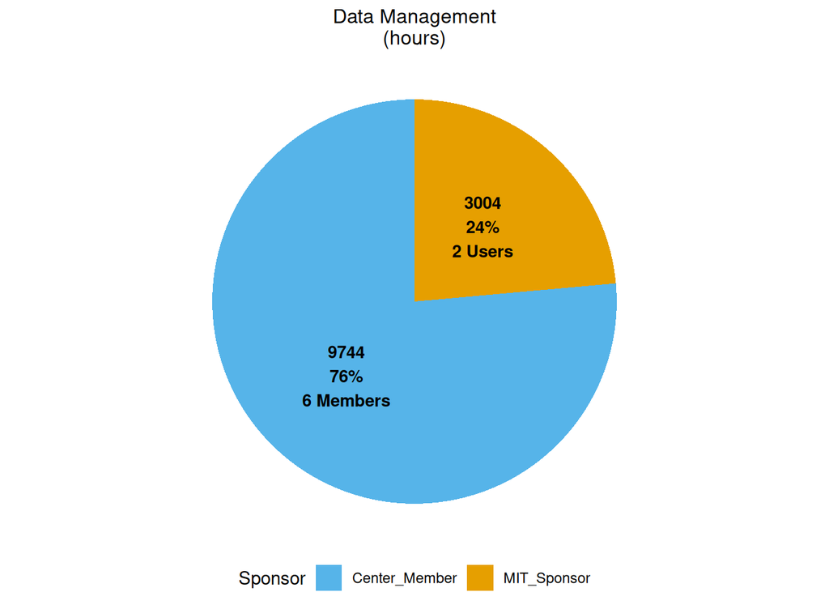

```r
dmac.hours.pie <- hours.dmac %>%
  mutate(Sponsor_ForPlot = factor(Sponsor_ForPlot, levels = sponsor_order)) %>%
  group_by(Sponsor_ForPlot) %>%
  summarise(Quantity = sum(round(Quantity,0)),
            Num_Labs = if_else(first(Sponsor_ForPlot) == "Center_Member",
                               n_distinct(Faculty.Key[IGT_DSMI_Sponsor == "KI_member"]),
                               n_distinct(Faculty.Key)),
            .groups = "drop") %>%
  mutate(Percent = round((Quantity / sum(Quantity)) * 100, 0),
         Lab_Label = if_else(Sponsor_ForPlot == "Center_Member",
                             paste0(Num_Labs, " Members"),
                             paste0(Num_Labs, " Users")),
         Label = paste0(Quantity, "\n", Percent, "%\n", Lab_Label)) %>%
  ggplot(aes(x = "", y = Quantity, fill = Sponsor_ForPlot)) +
  geom_col() +
  geom_text(aes(label = Label),
            position = position_stack(vjust = 0.5),
            size = 3.6,
            fontface = "bold",
            color = "black") +
  coord_polar("y", start = 0) +
  scale_fill_manual(values = sponsor_colors) +
  labs(title = "Data Management\n(hours)",
       fill = "Sponsor") +
  theme_void() +
  theme(legend.position = "bottom",
        plot.title = element_text(size = 12,
                                  face = "plain",
                                  hjust = 0.5))

dmac.hours.pie
```

# Plot the pie charts figure

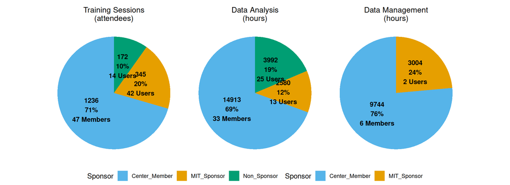

```r
train.pie + proj.hours.pie + dmac.hours.pie + plot_layout(ncol = 3, guides = "collect") &
  theme(legend.position = "bottom")
```

```r
combo.pie <- train.pie + proj.hours.pie + dmac.hours.pie + plot_layout(ncol = 3, guides = "collect") &
  theme(legend.position = "bottom")

ggsave("figures/DSMI_combo.pie.pdf",
       plot = combo.pie,
       dpi = 600,
       width = 11,
       height = 4,
       units = "in")
```

# Write annotated output file

```r
# write.xlsx(dsmi.final,"dsmi.final.xlsx")
```

```r
writeLines(capture.output(sessionInfo()), "DSMI_processing_sessionInfo.txt")
```